# ECON6027_4b_updated

Dr. Liu

## Spatial desctiptive summary measures

Start by loading the packages:

```r
library(aspace, quietly = T); library(sf)
```

### Datasets

```r
sg_regions = st_read("MP14_PLNG_AREA_WEB_PL.shp") # sg regions
table(st_is_valid(sg_regions)) # Validity must be checked for all loaded polygons
```

```
##
## FALSE  TRUE
##     8    47
```

```r
sg_regions = st_make_valid(sg_regions); table(st_is_valid(sg_regions))
```

```
##
## TRUE
##   55
```

```r
SLC = st_read("SPF_PSLC.shp") # speed laser cameras
table(st_is_valid(SLC)) # usually points objects have valid goemetry
```

[output not shown]

CRS matters: Before we conduct summary calculations, the unit of analysis must be in a metric form so that distance calculations will be meaningful. If the dataset follows a geographic CRS (st_is_longlat() is TRUE), then you must transform the CRS to a projected CRS.

```r
st_crs(sg_regions)$proj
```

```
## [1] "tmerc"
```

```r
st_crs(SLC)$proj
```

```
## [1] "tmerc"
```

```r
isTRUE(all.equal(st_crs(sg_regions), st_crs(SLC)))
```

```
## [1] TRUE
```

Both are projected with the same CRS. So, we are good to go!

### Initial maps

Start by creating a basemap “sg_map” and add the laser camera locations.

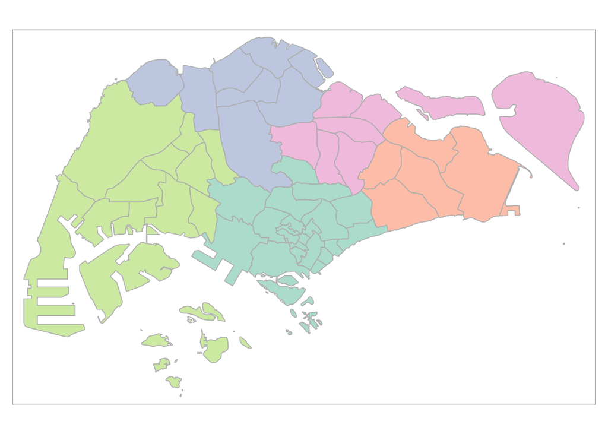

```r
library(tmap)
(sg_map = tm_shape(sg_regions) + tm_polygons(col="REGION_N", alpha=0.5,
                          border.col = "grey", palette="Set2", legend.show = F))
```

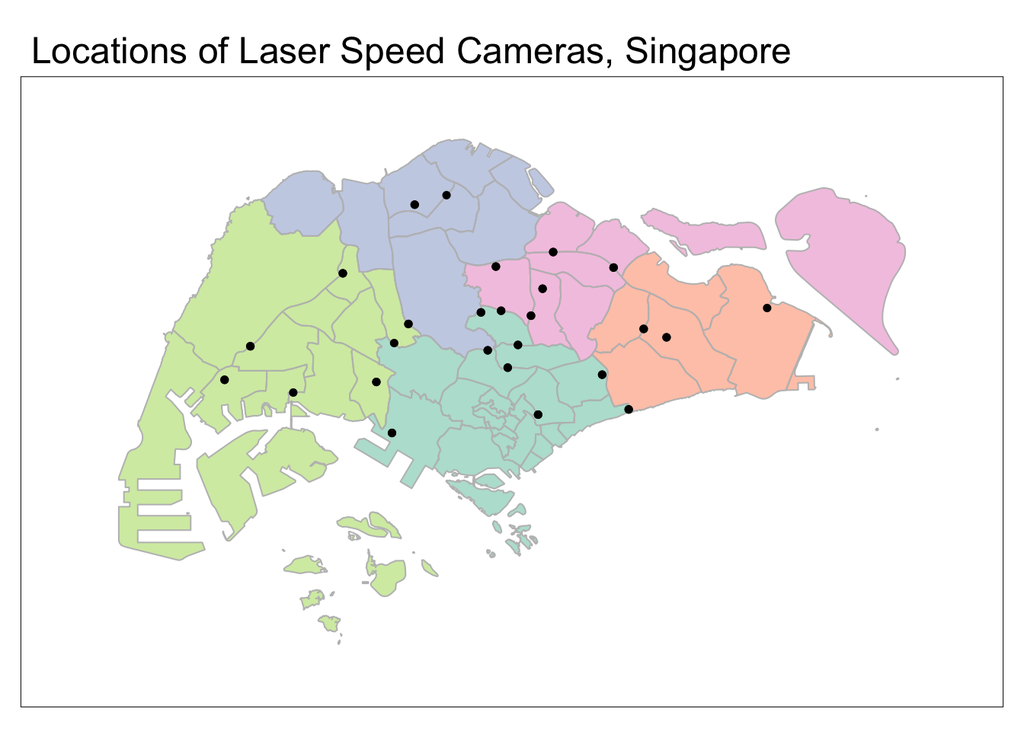

```r
(LC_locations = sg_map +
    tm_shape(SLC) + tm_dots(size=0.1) +
    tm_layout(main.title="Locations of Laser Speed Cameras, Singapore",
              inner.margins = 0.1))
```

### Descriptive summary measures

Computations using the aspace package functions can only be carried out on cartesian coordinates given in matrix form. Thus we will extract the coordinates of the speed laser camera locations of SLC.

```r
LC_coords = st_coordinates(SLC)
class(LC_coords)
```

```
## [1] "matrix" "array"
```

#### Measures of central tendency

Compute the mean and the median and assign it to a list object for later use.

```r
mean = calc_mnc(id=1, points=LC_coords)
mean$LOCATIONS
```

```
##      id       x        y
## [1,]  1 27775.2 37274.24
```

```r
median = calc_mdc(id=2, points= LC_coords)
median$LOCATIONS
```

```
##      id       x       y
## [1,]  2 28788.8 37013.8
```

#### SDD (standard distance disc)

In the following chunk, we compute the standard distance and the output is assigned to a list object called “sdd”.

```r
sdd = calc_sdd(id=3, calccentre = T, weighted=F, points = LC_coords)
```

In order to plot the standard distance disc using tmap, we need to convert standard distance disc contained in the list “sdd$LOCATIONS” created in the previous chunk to a sf line object.

```r
ls()
```

```
## [1] "LC_coords"    "LC_locations" "mean"         "median"       "sdd"
## [6] "sg_map"       "sg_regions"   "SLC"
```

```r
(LC_sdd_line = sdd$LOCATIONS %>% st_as_sf(coords = c("x", "y"), crs=st_crs(SLC))
    %>% st_combine() %>% st_cast("LINESTRING")) # CRS from the parent object.
```

```
## Geometry set for 1 feature
## Geometry type: LINESTRING
## Dimension:     XY
## Bounding box:  xmin: 18305.1 ymin: 27803.87 xmax: 37245.66 ymax: 46744.61
## Projected CRS: SVY21
```

```
## LINESTRING (37245.66 37274.24, 37244.2 37439.98...
```

```r
(LC_std_dist = st_sf(sdd$ATTRIBUTES, geom=st_geometry(LC_sdd_line)))
```

```
## Simple feature collection with 1 feature and 7 fields
## Geometry type: LINESTRING
## Dimension:     XY
## Bounding box:  xmin: 18305.1 ymin: 27803.87 xmax: 37245.66 ymax: 46744.61
## Projected CRS: SVY21
##   id calccentre weighted CENTRE.x CENTRE.y SDD.radius  SDD.area
## 1  3       TRUE    FALSE  27775.2 37274.24    9470.46 281768249
##                             geom
## 1 LINESTRING (37245.66 37274....
```

```r
# create sf object by adding in the attribute data
```

#### SDE (standard deviational ellipse)

Coding to generate the SDE is much similar to that of SDD above.

```r
sde = calc_sde(id=4, calccentre = T, weighted=F, points= LC_coords)
```

As before we convert standard deviational ellipse to sf line object to help with tmap mapping

```r
ls()
```

```
##  [1] "LC_coords"    "LC_locations" "LC_sdd_line"  "LC_std_dist"  "mean"
##  [6] "median"       "sdd"          "sde"          "sg_map"       "sg_regions"
## [11] "SLC"
```

```r
(LC_sde_line = sde$LOCATIONS %>% st_as_sf(coords = c("x", "y"), crs=st_crs(SLC))
  %>% st_combine() %>% st_cast("LINESTRING"))
```

```
## Geometry set for 1 feature
## Geometry type: LINESTRING
## Dimension:     XY
## Bounding box:  xmin: 15665.39 ymin: 31553.71 xmax: 39884.47 ymax: 42994.8
## Projected CRS: SVY21
```

```
## LINESTRING (39881.32 37934.9, 39861.35 38146.19...
```

```r
(LC_std_ellps = st_sf(sde$ATTRIBUTES, geom=st_geometry(LC_sde_line)))
```

```
## Simple feature collection with 1 feature and 19 fields
## Geometry type: LINESTRING
## Dimension:     XY
## Bounding box:  xmin: 15665.39 ymin: 31553.71 xmax: 39884.47 ymax: 42994.8
## Projected CRS: SVY21
##   id CALCCENTRE weighted CENTRE.x CENTRE.y Sigma.x  Sigma.y  Major  Minor
## 1  4       TRUE    FALSE  27775.2 37274.24 5690.74 12124.14 SigmaY SigmaX
##      Theta Eccentricity  Area.sde TanTheta  SinTheta   CosTheta
## 1 86.87634    0.8830001 216755177 18.32434 0.9985143 0.05449116
##   SinThetaCosTheta Sin2Theta   Cos2Theta ThetaCorr
## 1        0.0544102 0.9970307 0.002969286  86.87634
##                             geom
## 1 LINESTRING (39881.32 37934....
```

#### Plot of the summary measures

Create a point object with mean and median to be plotted as a separate layer. SDD and SDE will be added as additional layers. (Note the three different tm_shape layers).

```r
mean$LOCATIONS; median$LOCATIONS
```

```
##      id       x        y
## [1,]  1 27775.2 37274.24
```

```
##      id       x       y
## [1,]  2 28788.8 37013.8
```

```r
(mean_median = rbind(mean$LOCATIONS, median$LOCATIONS) %>% data.frame() %>%
  st_as_sf(coords=c("x","y"), crs=st_crs(SLC))) # matrix -> data.frame -> sf points
```

```
## Simple feature collection with 2 features and 1 field
## Geometry type: POINT
## Dimension:     XY
## Bounding box:  xmin: 27775.2 ymin: 37013.8 xmax: 28788.8 ymax: 37274.24
## Projected CRS: SVY21
##   id                 geometry
## 1  1 POINT (27775.2 37274.24)
## 2  2  POINT (28788.8 37013.8)
```

```r
mean_median$id = c("Spatial Mean","Spatial Median") # assign names
mean_median
```

```
## Simple feature collection with 2 features and 1 field
## Geometry type: POINT
## Dimension:     XY
## Bounding box:  xmin: 27775.2 ymin: 37013.8 xmax: 28788.8 ymax: 37274.24
## Projected CRS: SVY21
##               id                 geometry
## 1   Spatial Mean POINT (27775.2 37274.24)
## 2 Spatial Median  POINT (28788.8 37013.8)
```

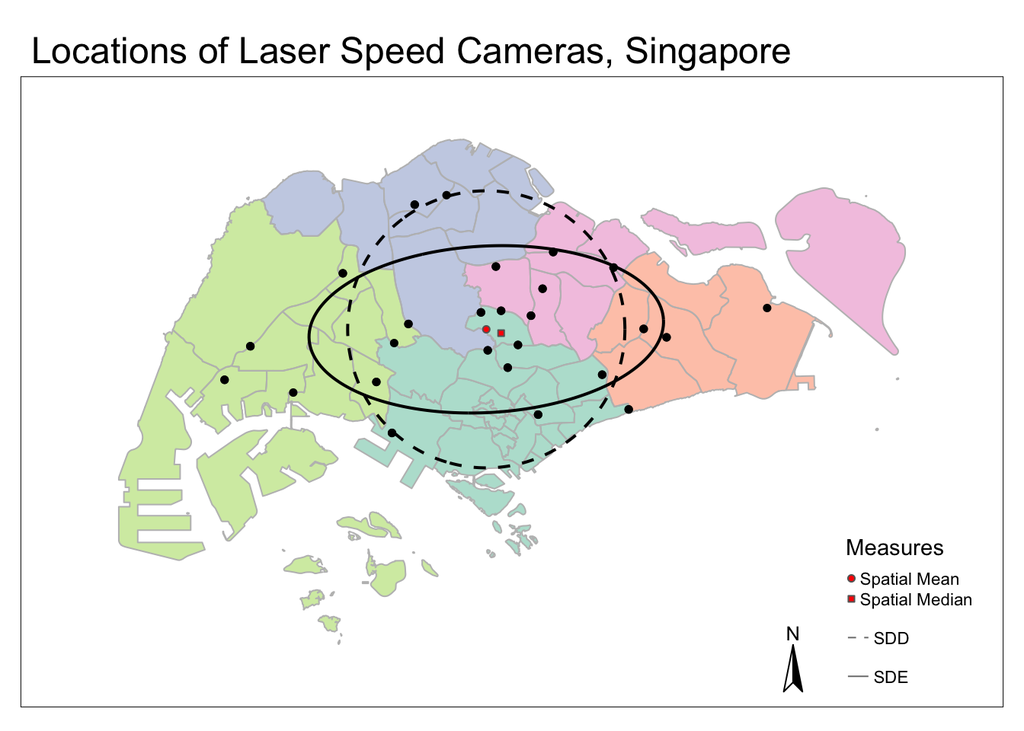

```r
LC_locations +
  tm_shape(LC_std_ellps) + tm_lines(lwd=2) +
  tm_shape(LC_std_dist) + tm_lines(lwd=2, lty=2) +
  tm_shape(mean_median) + tm_dots(size=0.1, shape="id", col="red", title.shape="Measures") +
  tm_compass() +
  tm_add_legend(type="line", labels="SDD", lty=2) +
  tm_add_legend(type="line", labels="SDE", lty=1)
```

### Weighted descriptive summary measures

We will use the dengue clusters as of May 2020 dataset for this analysis. The centroid of the clusters will be analysed. The weights are assigned based on the size of the cluster.

```r
dengue = st_read("dengue-clusters-may20.geojson") # original CRS is WGS84
st_is_longlat(dengue)
```

```
## [1] TRUE
```

```r
dengue = st_transform(dengue, crs=st_crs(sg_regions)) # align the CRS
isTRUE(all.equal(st_crs(sg_regions), st_crs(dengue)))
```

```
## [1] TRUE
```

```r
# Also check the validity of the geometry
table(st_is_valid(dengue))
```

```
##
## FALSE  TRUE
##     2   131
```

```r
dengue = st_make_valid(dengue); table(st_is_valid(dengue))
```

```
##
## TRUE
##  133
```

In the following chunk, we plot the dengue clusters on a map of Singapore.

```r
names(dengue)
```

```
## [1] "Name"        "Description" "geometry"
```

```r
dengue$area = st_area(dengue) # new attribute which will be used as weights later
summary(dengue$area)
```

```
##    Min. 1st Qu.  Median    Mean 3rd Qu.    Max.
##   28806   88936  131968  157258  196564  527196
```

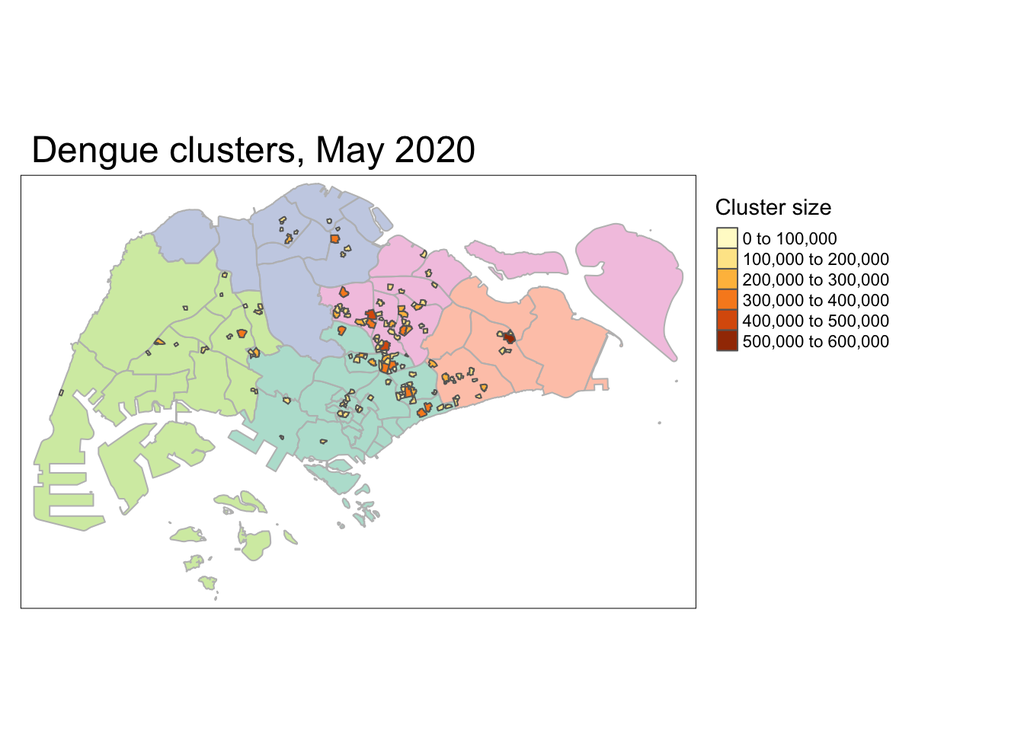

```r
sg_map +
  tm_shape(dengue) + tm_polygons(col="area", title="Cluster size") +
  tm_layout(main.title = "Dengue clusters, May 2020", legend.outside = T)
```

For the purpose of computing summary measures, extract the coordinates of the center of these clusters.

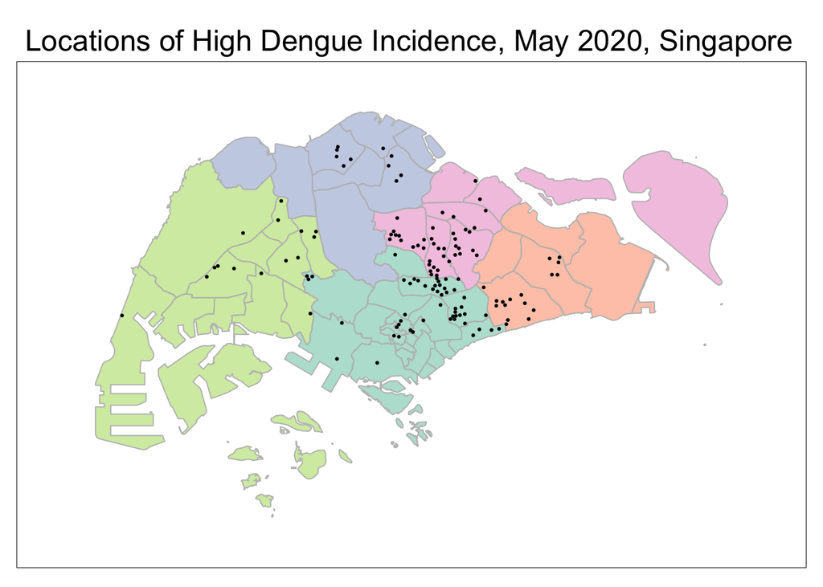

```r
dengue_spots = st_centroid(dengue)
dengue_coords = st_coordinates(dengue_spots) # extract coordinates from dengue_spots
(dengue_map = sg_map +
  tm_shape(dengue_spots) + tm_dots() +
  tm_layout(main.title="Locations of High Dengue Incidence, May 2020, Singapore",
            inner.margins = 0.1))
```

```r
(dengue_area = st_area(dengue))
```

```
## Units: [m^2]
##   [1] 374334.11 168120.26 239660.46 327837.45  46095.32 151731.65 196564.13
##   [8] 158866.70 190113.31 347728.37 223560.31 349879.92 196993.59 102680.82
##  [15] 110347.84 130824.68  73792.13 100100.79 122062.03 170797.35 182395.57
##  [22]  97683.66 172800.05 174835.71 123869.95  61997.56  54043.10  99840.11
##  [29] 120140.27  44764.11  51258.82 125562.75  73754.44  56926.27 210555.24
##  [36] 225640.60  86358.04 108148.16 153201.61 123150.10  55706.60  98730.47
##  [43] 123087.99 162092.22 211193.07 382516.18 483057.94 128598.82  89642.20
##  [50] 273042.54 377023.58 308213.87  65175.31 167520.72  86018.92  72919.08
##  [57] 166271.50 214400.84 219741.35 189867.62  90681.81  74713.13  95081.35
##  [64] 181425.03 527195.59 244689.39 357027.45 128165.18 387037.64 113790.77
##  [71] 419761.93  86217.52 286059.59  89907.16 201109.49  37649.80  44248.33
##  [78] 244128.91 179325.14  76370.38 150472.97 139811.91 152739.96 137413.67
##  [85] 105217.72 131968.39  67359.67 109186.42  35879.34 177547.32 142956.37
##  [92] 110703.72 151434.16 118757.60 195087.28 197343.43  71349.06  40592.06
##  [99] 135744.71 126434.25 139336.61  32145.07  62204.26 102447.96 156079.56
## [106]  88936.29 175262.69  88212.29  83210.35 164491.61 260650.99 317404.86
## [113]  82560.60 112707.97  28805.96 100741.32 231428.82  73361.40  44045.16
## [120] 172143.86 116751.33 206895.50 149160.13 284059.36  88757.80 141508.97
## [127] 156558.87  96199.82  75243.66 222162.68 122426.17 302936.62  70041.38
```

```r
class(dengue_area)
```

```
## [1] "units"
```

```r
(dengue_area = units::drop_units(st_area(dengue)))
```

```
##   [1] 374334.11 168120.26 239660.46 327837.45  46095.32 151731.65 196564.13
##   [8] 158866.70 190113.31 347728.37 223560.31 349879.92 196993.59 102680.82
##  [15] 110347.84 130824.68  73792.13 100100.79 122062.03 170797.35 182395.57
##  [22]  97683.66 172800.05 174835.71 123869.95  61997.56  54043.10  99840.11
##  [29] 120140.27  44764.11  51258.82 125562.75  73754.44  56926.27 210555.24
##  [36] 225640.60  86358.04 108148.16 153201.61 123150.10  55706.60  98730.47
##  [43] 123087.99 162092.22 211193.07 382516.18 483057.94 128598.82  89642.20
##  [50] 273042.54 377023.58 308213.87  65175.31 167520.72  86018.92  72919.08
##  [57] 166271.50 214400.84 219741.35 189867.62  90681.81  74713.13  95081.35
##  [64] 181425.03 527195.59 244689.39 357027.45 128165.18 387037.64 113790.77
##  [71] 419761.93  86217.52 286059.59  89907.16 201109.49  37649.80  44248.33
##  [78] 244128.91 179325.14  76370.38 150472.97 139811.91 152739.96 137413.67
##  [85] 105217.72 131968.39  67359.67 109186.42  35879.34 177547.32 142956.37
##  [92] 110703.72 151434.16 118757.60 195087.28 197343.43  71349.06  40592.06
##  [99] 135744.71 126434.25 139336.61  32145.07  62204.26 102447.96 156079.56
## [106]  88936.29 175262.69  88212.29  83210.35 164491.61 260650.99 317404.86
## [113]  82560.60 112707.97  28805.96 100741.32 231428.82  73361.40  44045.16
## [120] 172143.86 116751.33 206895.50 149160.13 284059.36  88757.80 141508.97
## [127] 156558.87  96199.82  75243.66 222162.68 122426.17 302936.62  70041.38
```

```r
class(dengue_area)
```

```
## [1] "numeric"
```

The measures are computed as follows (Note that the objects created in the previous section are being overwritten. If you want to create a new set of objects, change the name of the assignment):

```r
mean = calc_mnc(id=1, weighted = T, weights=dengue_area, points = dengue_coords)
sdd = calc_sdd(id=2, calccentre = T, weighted = T, weights = dengue_area, points = dengue_coords)
sde = calc_sde(id=3, calccentre = T, weighted = T, weights = dengue_area, points = dengue_coords)
```